# IODS course project

Dimitrios Tsallos

# About the project

*Hello data science world! You will find my repository [here](https://github.com/dtsallos/IODS-project). I am new to all that, but I have been learning fast, so let’s see how far I can manage with the many bugs here.*

# 1<sup>st</sup> Week

## Tools and methods for open and reproducible research

During the first week we went through the general instructions of the course, deadlines, tools to learn etc.- and start working! We get familiar with R, RStudio and GitHub. We create our own GitHub repository: a place on the web to store your course codes and analyses.

# 2<sup>nd</sup> Week

## Regression and model validation

This week we are learning how to manage with large datatables and create working size tables; a process called data wrangling. We then focus on data analysis, single and multiple regression analysis and model validation.

### Learning dataset

I will be mostly working with data produced by Kimmo Vehkalahti as part of his work for the study of:

> *“The relationship between learning approaches and students’ achievements in an introductory statistics course in Finland”*
- *Preliminary data were presented at a conference in Rio de Janeiro for the 60<sup>th</sup> World Statistics Congress - ISI2015. Slides are available [here](https://www.slideshare.net/kimmovehkalahti/the-relationship-between-learning-approaches-and-students-achievements-in-an-introductory-statistics-course-in-finland).*

I am using a shorter version of the dataset after shortening the table to a more manageable size. Here is the structure of the table:

```
## 'data.frame':    166 obs. of  7 variables:
##  $ gender  : Factor w/ 2 levels "F","M": 1 2 1 2 2 1 2 1 2 1 ...
##  $ Age     : int  53 55 49 53 49 38 50 37 37 42 ...
##  $ Attitude: int  37 31 25 35 37 38 35 29 38 21 ...
##  $ deep    : num  3.58 2.92 3.5 3.5 3.67 ...
##  $ stra    : num  3.38 2.75 3.62 3.12 3.62 ...
##  $ surf    : num  2.58 3.17 2.25 2.25 2.83 ...
##  $ Points  : int  25 12 24 10 22 21 21 31 24 26 ...
```

Here, you can see the same data in a table format for your interest.

|  | gender | Age | Attitude | deep | stra | surf | Points |
| --- | --- | --- | --- | --- | --- | --- | --- |
| 1 | F | 53 | 37 | 3.58333333333333 | 3.375 | 2.58333333333333 | 25 |
| 2 | M | 55 | 31 | 2.91666666666667 | 2.75 | 3.16666666666667 | 12 |
| 3 | F | 49 | 25 | 3.5 | 3.625 | 2.25 | 24 |
| 4 | M | 53 | 35 | 3.5 | 3.125 | 2.25 | 10 |
| 5 | M | 49 | 37 | 3.66666666666667 | 3.625 | 2.83333333333333 | 22 |
| 6 | F | 38 | 38 | 4.75 | 3.625 | 2.41666666666667 | 21 |
| 7 | M | 50 | 35 | 3.83333333333333 | 2.25 | 1.91666666666667 | 21 |
| 8 | F | 37 | 29 | 3.25 | 4 | 2.83333333333333 | 31 |
| 9 | M | 37 | 38 | 4.33333333333333 | 4.25 | 2.16666666666667 | 24 |
| 10 | F | 42 | 21 | 4 | 3.5 | 3 | 26 |

[output cut: 156 more lines]

Here is a summary table of the above data:

```
##  gender       Age           Attitude          deep            stra
##  F:110   Min.   :17.00   Min.   :14.00   Min.   :1.583   Min.   :1.250
##  M: 56   1st Qu.:21.00   1st Qu.:26.00   1st Qu.:3.333   1st Qu.:2.625
##          Median :22.00   Median :32.00   Median :3.667   Median :3.188
##          Mean   :25.51   Mean   :31.43   Mean   :3.680   Mean   :3.121
##          3rd Qu.:27.00   3rd Qu.:37.00   3rd Qu.:4.083   3rd Qu.:3.625
##          Max.   :55.00   Max.   :50.00   Max.   :4.917   Max.   :5.000
##       surf           Points
##  Min.   :1.583   Min.   : 7.00
##  1st Qu.:2.417   1st Qu.:19.00
##  Median :2.833   Median :23.00
##  Mean   :2.787   Mean   :22.72
##  3rd Qu.:3.167   3rd Qu.:27.75
##  Max.   :4.333   Max.   :33.00
```

But for better visualisation and understanding of the relationship from the available variables, here is a paired plot:

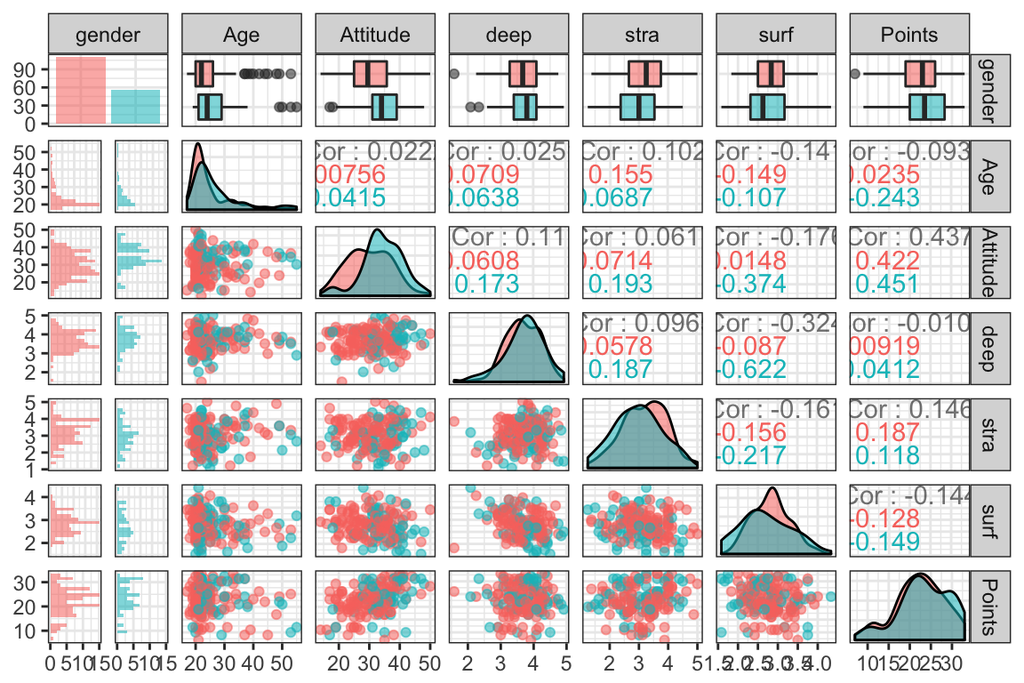

## Creating a regression model

> Let’s see what is the most significant factor affecting the final exam points of a student.

First, how is the exam points scored affected by the student’s attitude, age and strategic skills (based on their average response to strategic questions).

```
##
## Call:
## lm(formula = Points ~ Attitude + Age + stra, data = learning2014)
##
## Residuals:
##      Min       1Q   Median       3Q      Max
## -18.1149  -3.2003   0.3303   3.4129  10.7599
##
## Coefficients:
##             Estimate Std. Error t value Pr(>|t|)
## (Intercept) 10.89543    2.64834   4.114 6.17e-05 ***
## Attitude     0.34808    0.05622   6.191 4.72e-09 ***
## Age         -0.08822    0.05302  -1.664   0.0981 .
## stra         1.00371    0.53434   1.878   0.0621 .
## ---
## Signif. codes:  0 '***' 0.001 '**' 0.01 '*' 0.05 '.' 0.1 ' ' 1
##
## Residual standard error: 5.26 on 162 degrees of freedom
## Multiple R-squared:  0.2182, Adjusted R-squared:  0.2037
## F-statistic: 15.07 on 3 and 162 DF,  p-value: 1.07e-08
```

Here, is the summary of the linear model with the two parameters alone:

```
##
## Call:
## lm(formula = Points ~ Attitude, data = learning2014)
##
## Residuals:
##      Min       1Q   Median       3Q      Max
## -16.9763  -3.2119   0.4339   4.1534  10.6645
##
## Coefficients:
##             Estimate Std. Error t value Pr(>|t|)
## (Intercept) 11.63715    1.83035   6.358 1.95e-09 ***
## Attitude     0.35255    0.05674   6.214 4.12e-09 ***
## ---
## Signif. codes:  0 '***' 0.001 '**' 0.01 '*' 0.05 '.' 0.1 ' ' 1
##
## Residual standard error: 5.32 on 164 degrees of freedom
## Multiple R-squared:  0.1906, Adjusted R-squared:  0.1856
## F-statistic: 38.61 on 1 and 164 DF,  p-value: 4.119e-09
```

This univariate model explains that the variable of exam points scored is significantly related to the students attitude (p-value > 0). At a theoretical attitude value of zero the points scored would be 11.64 with a standard error 1.83. For every point of attitude increased, there is 0.35 more exam points scored with a standard error of 0.06.

R-squared is always between 0 and 1 (and as percentage when multiplied by 100): 0% indicates that the model explains none of the variability of the response data around its mean. 100% indicates that the model explains all the variability of the response data around its mean. Multiple R-squared is used for evaluating how well the model fits the data. In this case, Multiple R-squared value of 0.19 implies that the model can explain only 19% of the variation in the outcome.

So, this is how the model actually looks like:

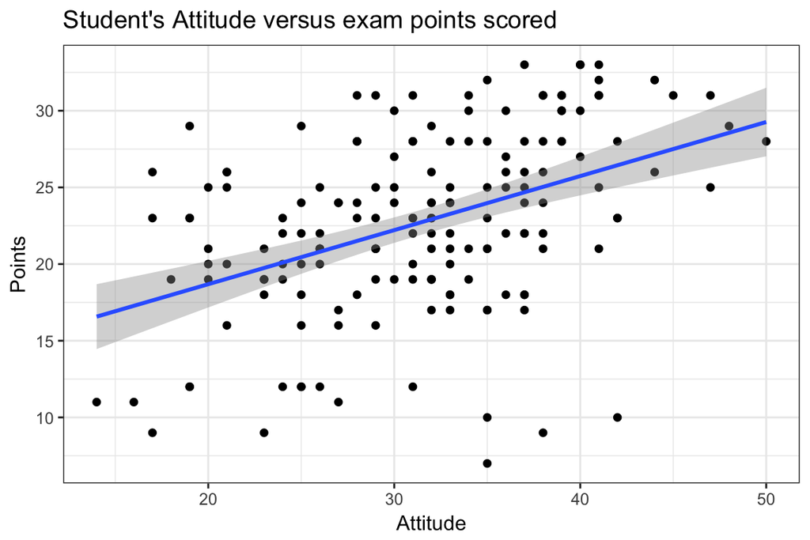

## Graphical model validation

R makes it easy to graphically explore the validity of your model assumptions. If you give a linear model object as the first argument to the plot() function, the function automatically assumes you want diagnostic plots and will produce them. You can check the help page of plotting an lm object by typing ?plot.lm or help(plot.lm) to the R console.

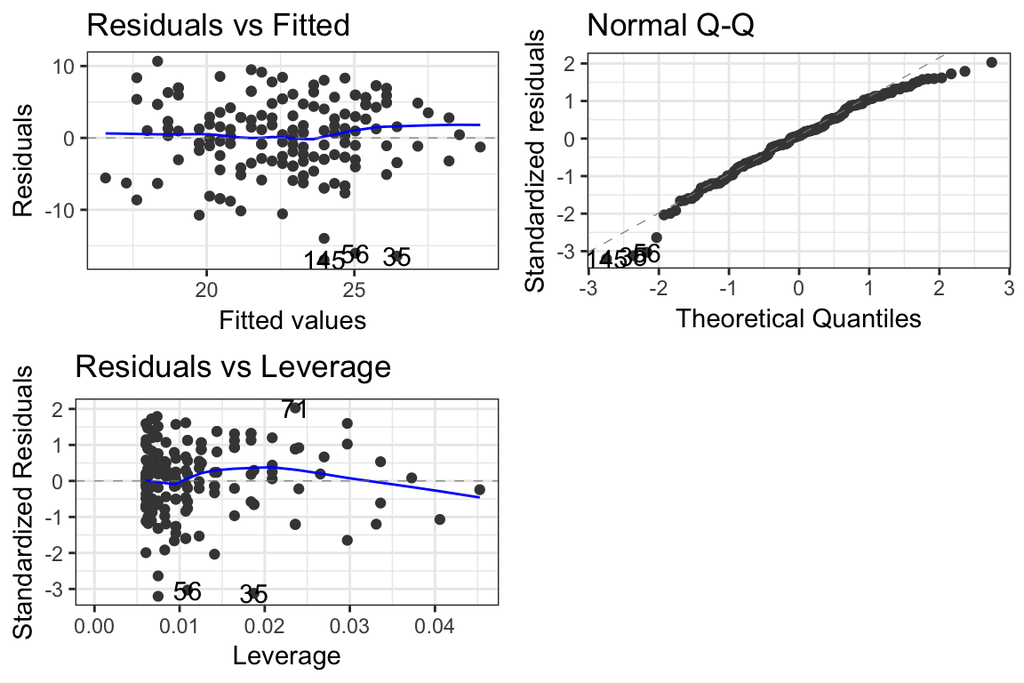

### Residuals vs Fitted plot

**The Residuals vs Fitted plot** studies the variance of the residuals. This plot represents the deviation of the observed values of an element of a statistical sample from its “theoretical value”. The residual of an observed value is the difference between the observed value and the estimated value of the quantity of interest. Here, the linearity of the regression model is supported by a homogeneity of variance (or homoscedasticity) with residuals that appear close to 10 points difference from the fitted values. This is off course with the exception of the observations 145, 56 and 35. * In other words: + We are looking at how well the model describes the variables we are interested in + The target variable is modelled as a linear combination of the model parameters + Errors are normally distributed and have constant variance

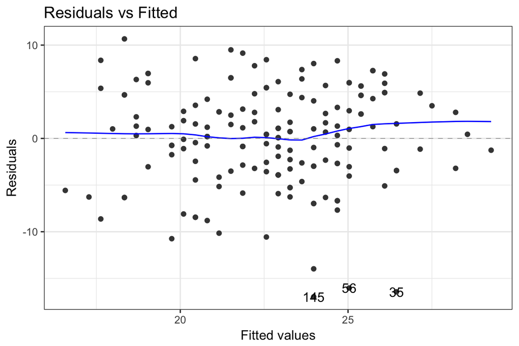

### Normal Q-Q plot

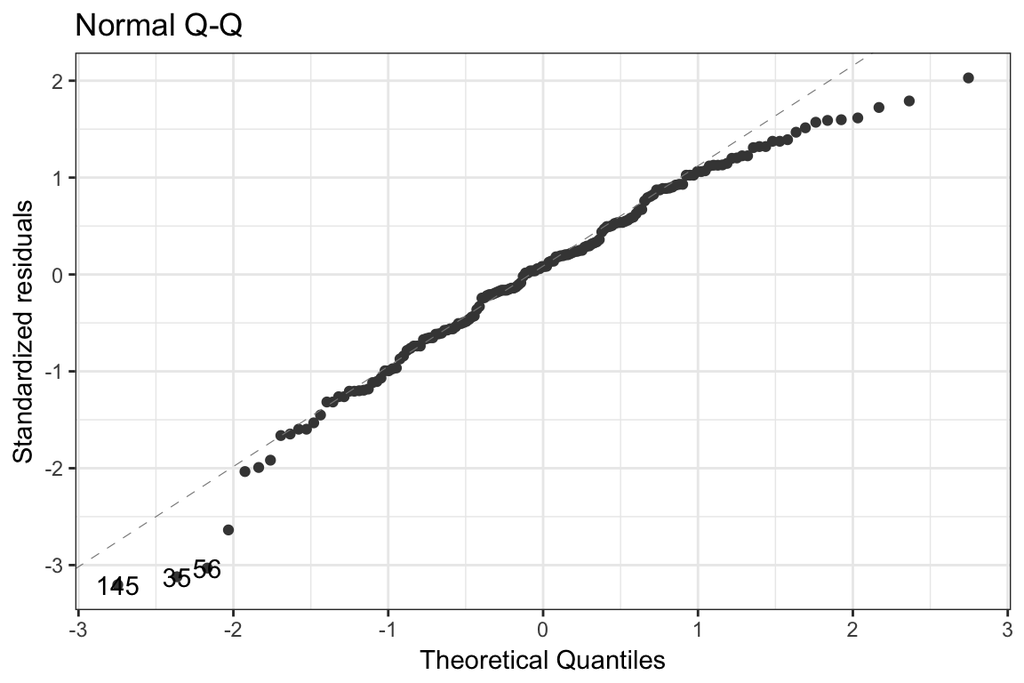

### Residuals vs Leverage plot

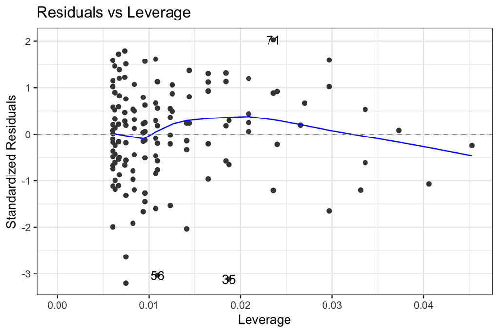

*Note: A very good explanation came from this [link](https://stats.stackexchange.com/questions/58141/interpreting-plot-lm).*

# 3<sup>nd</sup> Week

## Logistic Regression

### Student performance dataset

This week, we are working with a new dataset. This data approach student achievement in secondary education of two Portuguese schools. The data attributes include student grades, demographic, social and school related features) and it was collected by using school reports and questionnaires. Two datasets are provided regarding the performance in two distinct subjects: Mathematics (mat) and Portuguese language (por). In [Cortez and Silva, 2008], the two datasets were modeled under binary/five-level classification and regression tasks.

*You can find out more about this dataset and the related study [here](https://archive.ics.uci.edu/ml/datasets/Student+Performance).*

But here is the variable names included in the following analysis:

```
##  [1] "school"     "sex"        "age"        "address"    "famsize"
##  [6] "Pstatus"    "Medu"       "Fedu"       "Mjob"       "Fjob"
## [11] "reason"     "nursery"    "internet"   "guardian"   "traveltime"
## [16] "studytime"  "failures"   "schoolsup"  "famsup"     "paid"
## [21] "activities" "higher"     "romantic"   "famrel"     "freetime"
## [26] "goout"      "Dalc"       "Walc"       "health"     "absences"
## [31] "G1"         "G2"         "G3"         "alc_use"    "high_use"
```

And here is how the data has been structured:

```
## 'data.frame':    382 obs. of  35 variables:
##  $ school    : Factor w/ 2 levels "GP","MS": 1 1 1 1 1 1 1 1 1 1 ...
##  $ sex       : Factor w/ 2 levels "F","M": 1 1 1 1 1 2 2 1 2 2 ...
##  $ age       : int  18 17 15 15 16 16 16 17 15 15 ...
##  $ address   : Factor w/ 2 levels "R","U": 2 2 2 2 2 2 2 2 2 2 ...
##  $ famsize   : Factor w/ 2 levels "GT3","LE3": 1 1 2 1 1 2 2 1 2 1 ...
##  $ Pstatus   : Factor w/ 2 levels "A","T": 1 2 2 2 2 2 2 1 1 2 ...
##  $ Medu      : int  4 1 1 4 3 4 2 4 3 3 ...
##  $ Fedu      : int  4 1 1 2 3 3 2 4 2 4 ...
##  $ Mjob      : Factor w/ 5 levels "at_home","health",..: 1 1 1 2 3 4 3 3 4 3 ...
##  $ Fjob      : Factor w/ 5 levels "at_home","health",..: 5 3 3 4 3 3 3 5 3 3 ...
##  $ reason    : Factor w/ 4 levels "course","home",..: 1 1 3 2 2 4 2 2 2 2 ...
##  $ nursery   : Factor w/ 2 levels "no","yes": 2 1 2 2 2 2 2 2 2 2 ...
##  $ internet  : Factor w/ 2 levels "no","yes": 1 2 2 2 1 2 2 1 2 2 ...
##  $ guardian  : Factor w/ 3 levels "father","mother",..: 2 1 2 2 1 2 2 2 2 2 ...
```

[output cut: 21 more lines]

## Hypothesis

Using the given data, we are going to study student’s behavior with regards to alcohol consumption. According to stereotypes, students who are being raised by one of the two parents alone (Pstatus = A, “apart”) are more likely to seek alcohol to soothen emotional distress. When those students are members of big families (famsize = GT3, “greater than 3”) the situation could lead to higher alcohol consumption. These students are also more likely to miss class (absences are numeric from 0 to 93). While those students who are busy with extracurricular activities (activities = yes) could be distracted, get more supervision and support which leads to less alcohol consumption and less abcences recorded from class. Let’s study now if that is true based on the given data sample.

famsize - family size (binary: ‘LE3’ - less or equal to 3 or ‘GT3’ - greater than 3)

Pstatus - parent’s cohabitation status (binary: ‘T’ - living together or ‘A’ - apart)

activities - extra-curricular activities (binary: yes or no)

absences - number of school absences (numeric: from 0 to 93)

## Visualise data trends

Numerically and graphically explore the distributions of your chosen variables and their relationships with alcohol consumption (use for example cross-tabulations, bar plots and box plots). Comment on your findings and compare the results of your exploration to your previously stated hypotheses. (0-5 points)

```
##
##
##    Cell Contents
## |-------------------------|
## |                       N |
## | Chi-square contribution |
## |           N / Row Total |
## |           N / Col Total |
## |         N / Table Total |
## |-------------------------|
##
##
## Total Observations in Table:  382
##
##
##                  | Family size
## High alcohol use |       GT3 |       LE3 | Row Total |
## -----------------|-----------|-----------|-----------|
##            FALSE |       201 |        67 |       268 |
##                  |     0.182 |     0.487 |           |
##                  |     0.750 |     0.250 |     0.702 |
##                  |     0.723 |     0.644 |           |
##                  |     0.526 |     0.175 |           |
## -----------------|-----------|-----------|-----------|
##             TRUE |        77 |        37 |       114 |
##                  |     0.429 |     1.146 |           |
##                  |     0.675 |     0.325 |     0.298 |
##                  |     0.277 |     0.356 |           |
##                  |     0.202 |     0.097 |           |
## -----------------|-----------|-----------|-----------|
##     Column Total |       278 |       104 |       382 |
##                  |     0.728 |     0.272 |           |
## -----------------|-----------|-----------|-----------|
##
##
```

```
##
##
##    Cell Contents
## |-------------------------|
## |                       N |
## | Chi-square contribution |
## |           N / Row Total |
## |           N / Col Total |
## |         N / Table Total |
## |-------------------------|
##
##
## Total Observations in Table:  382
##
##
##                  | Parental status
## High alcohol use |         A |         T | Row Total |
## -----------------|-----------|-----------|-----------|
##            FALSE |        26 |       242 |       268 |
##                  |     0.016 |     0.002 |           |
##                  |     0.097 |     0.903 |     0.702 |
##                  |     0.684 |     0.703 |           |
##                  |     0.068 |     0.634 |           |
## -----------------|-----------|-----------|-----------|
##             TRUE |        12 |       102 |       114 |
##                  |     0.038 |     0.004 |           |
##                  |     0.105 |     0.895 |     0.298 |
##                  |     0.316 |     0.297 |           |
##                  |     0.031 |     0.267 |           |
## -----------------|-----------|-----------|-----------|
##     Column Total |        38 |       344 |       382 |
##                  |     0.099 |     0.901 |           |
## -----------------|-----------|-----------|-----------|
##
##
```

```
##
##
##    Cell Contents
## |-------------------------|
## |                       N |
## | Chi-square contribution |
## |           N / Row Total |
## |           N / Col Total |
## |         N / Table Total |
## |-------------------------|
##
##
## Total Observations in Table:  382
##
##
##                  | Extra-curricular activities
## High alcohol use |        no |       yes | Row Total |
## -----------------|-----------|-----------|-----------|
##            FALSE |       122 |       146 |       268 |
##                  |     0.196 |     0.176 |           |
##                  |     0.455 |     0.545 |     0.702 |
##                  |     0.674 |     0.726 |           |
##                  |     0.319 |     0.382 |           |
## -----------------|-----------|-----------|-----------|
##             TRUE |        59 |        55 |       114 |
##                  |     0.460 |     0.414 |           |
##                  |     0.518 |     0.482 |     0.298 |
##                  |     0.326 |     0.274 |           |
##                  |     0.154 |     0.144 |           |
## -----------------|-----------|-----------|-----------|
##     Column Total |       181 |       201 |       382 |
##                  |     0.474 |     0.526 |           |
## -----------------|-----------|-----------|-----------|
##
##
```

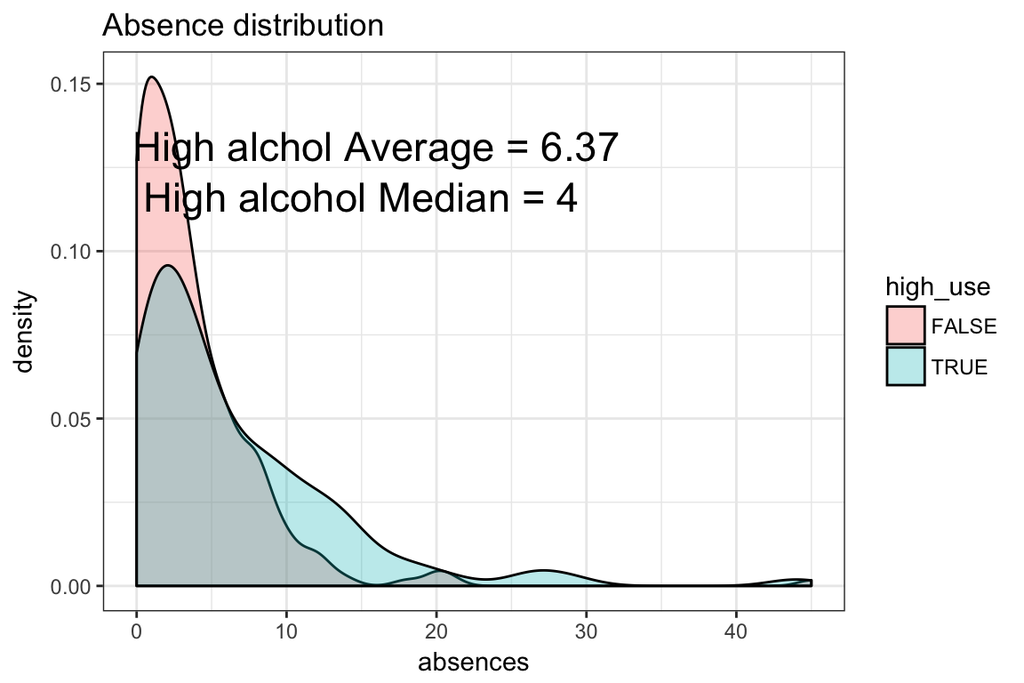

### Logistic Regretion

Here is a summary of the fitted model testing the above hypothesis. This summary includes odds ratios and confidence intervals:

```
##
## Call:
## glm(formula = high_use ~ (alc$famsize == "GT3") + (activities ==
##     "no") + (Pstatus == "A") + absences, family = "binomial",
##     data = alc)
##
## Deviance Residuals:
##     Min       1Q   Median       3Q      Max
## -2.3113  -0.8113  -0.7152   1.2350   1.8822
##
## Coefficients:
##                          Estimate Std. Error z value Pr(>|z|)
## (Intercept)              -1.12493    0.26973  -4.171 3.04e-05 ***
## alc$famsize == "GT3"TRUE -0.36857    0.25541  -1.443    0.149
## activities == "no"TRUE    0.26059    0.23174   1.124    0.261
## Pstatus == "A"TRUE       -0.27378    0.40287  -0.680    0.497
## absences                  0.09125    0.02324   3.926 8.62e-05 ***
## ---
## Signif. codes:  0 '***' 0.001 '**' 0.01 '*' 0.05 '.' 0.1 ' ' 1
##
## (Dispersion parameter for binomial family taken to be 1)
##
##     Null deviance: 465.68  on 381  degrees of freedom
## Residual deviance: 443.94  on 377  degrees of freedom
## AIC: 453.94
##
## Number of Fisher Scoring iterations: 4
```

```
##              (Intercept) alc$famsize == "GT3"TRUE   activities == "no"TRUE
##              -1.12493318              -0.36856686               0.26059001
##       Pstatus == "A"TRUE                 absences
##              -0.27378186               0.09124544
```

```
##                                 OR     2.5 %    97.5 %
## (Intercept)              0.3246742 0.1885776 0.5444944
## alc$famsize == "GT3"TRUE 0.6917250 0.4204341 1.1469385
## activities == "no"TRUE   1.2976955 0.8240954 2.0472447
## Pstatus == "A"TRUE       0.7604980 0.3320593 1.6307745
## absences                 1.0955379 1.0488999 1.1490038
```

### Explore predictive power

Using the variables which, according to your logistic regression model, had a statistical relationship with high/low alcohol consumption, explore the predictive power of you model. Provide a 2x2 cross tabulation of predictions versus the actual values and optionally display a graphic visualizing both the actual values and the predictions. Compute the total proportion of inaccurately classified individuals (= the training error) and comment on all the results. Compare the performance of the model with performance achieved by some simple guessing strategy. (0-3 points)

Here is how my current model is performing:

```
##         prediction
## high_use      FALSE       TRUE        Sum
##    FALSE 0.68062827 0.02094241 0.70157068
##    TRUE  0.26701571 0.03141361 0.29842932
##    Sum   0.94764398 0.05235602 1.00000000
```

My hypothesis was pretty bad and it is proven by this data. At least my faith in humanity is now restored and some kind of easy stereotypes can be ignored (as they already were).

The variables that actually work from my model are here:

```
##
## Call:
## glm(formula = high_use ~ absences, family = "binomial", data = alc)
##
## Deviance Residuals:
##     Min       1Q   Median       3Q      Max
## -2.3754  -0.8181  -0.7282   1.2652   1.7475
##
## Coefficients:
##             Estimate Std. Error z value Pr(>|z|)
## (Intercept) -1.28190    0.15920  -8.052 8.12e-16 ***
## absences     0.08982    0.02299   3.907 9.36e-05 ***
## ---
## Signif. codes:  0 '***' 0.001 '**' 0.01 '*' 0.05 '.' 0.1 ' ' 1
##
## (Dispersion parameter for binomial family taken to be 1)
##
##     Null deviance: 465.68  on 381  degrees of freedom
## Residual deviance: 447.45  on 380  degrees of freedom
## AIC: 451.45
##
## Number of Fisher Scoring iterations: 4
```

```
## (Intercept)    absences
## -1.28189927  0.08981766
```

```
##                   OR2     2.5 %    97.5 %
## (Intercept) 0.2775097 0.2012914 0.3760343
## absences    1.0939748 1.0479459 1.1468072
```

I know, it is only one variable…but it seems that students who missed class regularly are more likely to be at risk of being high alcohol consumers.

Let’s see how these two models compare with a likelihood ratio test:

```
## Analysis of Deviance Table
##
## Model 1: high_use ~ (alc$famsize == "GT3") + (activities == "no") + (Pstatus ==
##     "A") + absences
## Model 2: high_use ~ absences
##   Resid. Df Resid. Dev Df Deviance Pr(>Chi)
## 1       377     443.94
## 2       380     447.45 -3   -3.502   0.3205
```

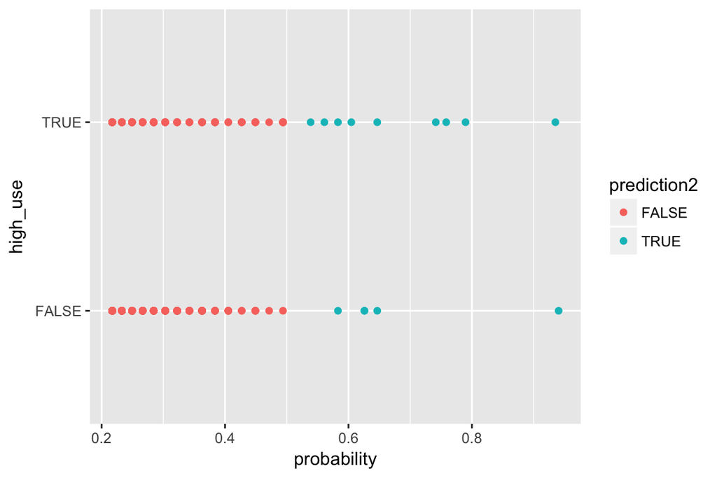

```
##         prediction
## high_use      FALSE       TRUE        Sum
##    FALSE 0.68848168 0.01308901 0.70157068
##    TRUE  0.27486911 0.02356021 0.29842932
##    Sum   0.96335079 0.03664921 1.00000000
```

### Apologies

I am sorry if you have to correct this work, it is done last minute and on the fly. Bad timing to realise that I hadn’t understood/needed to study more regarding the topic of this week’s matterial. Good luck with your assignment. :)